# PanCan IRWG Tumor Clonality Correlative Analysis

James A. Eddy

2017-07-21

# Summary

Exploring associations of tumor clonality across tumor types in TCGA with suggested correlates defined by the Immune Response Working Group:

- Overall Leukocyte fraction
- Individual Relative CIBERSORT fraction
- Mutation Load
- TCR,BCR Diversity
- Gene expression

# Prepare data

## Retrieve clonality data from Synapse

Data are stored on Synapse in the folder `syn4602485` for “Aneuploidy and Copy number”.

Aneuploidy and Copy number: syn4602485 syn7300639 (“Purity_Ploidy_All_Samples_9_28_16.tsv”) filename: “TCGA_mastercalls.abs_tables_JSedit.fixed.txt”

```r
if (!dir.exists("../data")) {
    dir.create("../data")
}
synapseLogin()
```

[output not shown]

```r
# file_data <- synGet("syn7300639", downloadLocation = "./data/tcga")
clonality_file <- "../data/tcga/TCGA_mastercalls.abs_tables_JSedit.fixed.txt"
clonality_df <- read_tsv(clonality_file)
```

## Sample filtering

Sample Quality Annotations: syn4551248 (“merged_sample_quality_annotations.tsv”)

```r
sample_qual_file <- synGet("syn4551248", downloadLocation = "../data/tcga/")
sample_qual_df <- sample_qual_file %>%
    getFileLocation() %>%
    read_tsv()
```

Remove samples based on `Do_not_use=True`, and remove cases with `AWG_excluded_because_of_pathology=True`.

```r
# samples to exclude from all datasets
exclude_samples <- sample_qual_df %>%
    mutate(AWG_excluded_because_of_pathology = parse_logical(AWG_excluded_because_of_pathology),
           Do_not_use = parse_logical(str_to_upper(Do_not_use))) %>%
    filter(AWG_excluded_because_of_pathology | Do_not_use)
```

Remove samples from clonality dataset, add disease types. Also remove samples with missing values for subclonal faction. Add additional column to store vial ID (to ease mapping between data sets).

```r
clonality_corr_df <- clonality_df %>%
    filter(!(sample %in% exclude_samples$aliquot_barcode),
           !is.na(`Subclonal genome fraction`)) %>%
    left_join(sample_qual_df %>%
                  select(aliquot_barcode, `cancer type`),
              by = c("sample" = "aliquot_barcode")) %>%
    mutate(vial_id = str_replace(sample, "(\\-[:alnum:]+){3}$", ""))
```

## Set up plotting colors

```r
tcga_colors <- tribble(
    ~Color, ~Disease,
    "#ED2891", "BRCA",
    "#B2509E", "GBM",
    "#D49DC7", "LGG",
    "#C1A72F", "ACC",
    "#E8C51D", "PCPG",
    "#F9ED32", "THCA",
    "#104A7F", "CHOL",
    "#9EDDF9", "COAD",
    "#007EB5", "ESCA",
    "#CACCDB", "LIHC",
    "#6E7BA2", "PAAD",
    "#DAF1FC", "READ",
    "#00AEEF", "STAD",
    "#F6B667", "CESC",
    "#D97D25", "OV",
    "#FBE3C7", "UCEC",
    "#F89420", "UCS",
    "#97D1A9", "HNSC",
    "#009444", "UVM",
    "#754C29", "LAML",
    "#CEAC8F", "THYM",
    "#3953A4", "DLBC",
    "#BBD642", "SKCM",
    "#00A99D", "SARC",
    "#D3C3E0", "LUAD",
    "#A084BD", "LUSC",
    "#542C88", "MESO",
    "#FAD2D9", "BLCA",
    "#ED1C24", "KICH",
    "#F8AFB3", "KIRC",
    "#EA7075", "KIRP",
    "#7E1918", "PRAD",
    "#BE1E2D", "TGCT"
)
clonality_corr_df <- clonality_corr_df %>%
    dplyr::rename(Disease = `cancer type`) %>%
    mutate(Disease = factor(Disease, levels = tcga_colors$Disease))
```

# Explore clonality data

## Sample characteristics

Note: between the clonality and sample quality data, I don’t have any clear indication of sample type. I may want to use another source (e.g., the miRNA sample data) to filter for primary tumors only.

## Subclonal fraction values

I can look at the distribution of subclonal fraction values with boxplots:

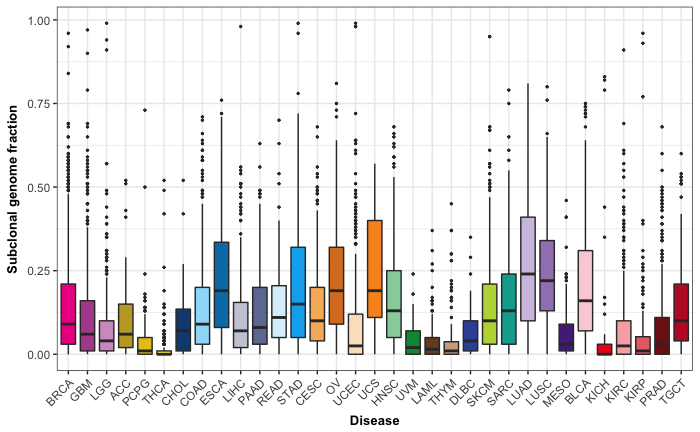

```r
clonality_corr_df %>%
    ggplot(aes(x = Disease, y = `Subclonal genome fraction`)) +
    geom_boxplot(aes(fill = Disease), alpha = 1, outlier.size = 0.5) +
    theme(axis.text.x = element_text(angle = 45, hjust = 1)) +
    scale_fill_manual(values = tcga_colors$Color) +
    guides(fill = FALSE)
```

# Prepare correlate data

- Overall Leukocyte fraction
- Individual Relative CIBERSORT fraction
- Mutation Load
- TCR,BCR Diversity
- Gene Expression

## Leukocyte fraction

### Retrieve/load data

Cellular Content: syn7994728 syn5808205 (“TCGA_all_leuk_estimate.masked.20170107.tsv”)

```r
# file_data <- synGet("syn5808205", downloadLocation = "./")
leuk_frac_file <- "../data/tcga/TCGA_all_leuk_estimate.masked.20170107.tsv"
leuk_frac_df <- read_tsv(leuk_frac_file, col_names = FALSE) %>%
    set_names(c("disease", "id", "leuk_frac"))
```

### Sample filtering

```r
leuk_frac_df <- leuk_frac_df %>%
    filter(!(id %in% exclude_samples$aliquot_barcode))
```

### Sample matching

Identify matched samples between miRNA and leukocyte fraction.

```r
leuk_frac_ids <- leuk_frac_df %>%
    select(id) %>%
    mutate(vial_id = str_replace(id, "(\\-[:alnum:]+){3}$", "")) %>%
    arrange()
clonality_ids <- clonality_corr_df %>%
    select(id = sample, vial_id) %>%
    arrange()
clonality_leuk_frac_shared_ids <- inner_join(clonality_ids, leuk_frac_ids,
                                         by = "vial_id",
                                         suffix = c("_clonality", "_leuk_frac"))
# only keep samples with matched vial ID AND portion number
portion_id_minus_analyte_regex <- "([:alnum:]+\\-){4}[0-9]+"
# plate_id_only_regex <- "[:alnum:]+(?=([:alnum:]\\-[:alnum:]+){1}$)"
clonality_leuk_frac_shared_ids <- clonality_leuk_frac_shared_ids %>%
    filter((str_extract(id_clonality, portion_id_minus_analyte_regex)
            == str_extract(id_leuk_frac, portion_id_minus_analyte_regex)))
```

NOTE: several samples were assayed on multiple plates; average the leukocyte fraction across these before computing correlations with miRNA

### Correlate data formatting

```r
leuk_frac_corr_file <- "../data/intermediate/leuk_frac_correlates_for_clonality.feather"
force_format <- FALSE
if (!file.exists(leuk_frac_corr_file) | force_format) {
    leuk_frac_corr_df <- clonality_leuk_frac_shared_ids %>%
        left_join(leuk_frac_df, by = c("id_leuk_frac" = "id")) %>%
        group_by(disease, vial_id) %>%
        summarise(leuk_frac = mean(leuk_frac)) %>%
        ungroup()

    write_feather(leuk_frac_corr_df, leuk_frac_corr_file)
} else {
    leuk_frac_corr_df <- read_feather(leuk_frac_corr_file)
}
```

### Disease-wise correlations

```r
if (!dir.exists("../results")) {
    dir.create("../results")
}
clonality_leuk_frac_corr_file <- "../results/clonality_leuk_frac_correlation.feather"
force_compute <- FALSE
if (!file.exists(clonality_leuk_frac_corr_file) | force_compute) {
    # skip immune cell cancers?
    d_list <- clonality_corr_df %>%
        # filter((!Disease %in% c("LAML", "THYM", "DLBC"))) %>%
        filter(Disease %in% leuk_frac_corr_df$disease) %>%
        distinct(Disease) %>%
        mutate(Disease = as.character(Disease)) %>%
        .$Disease %>%
        set_names(.) %>%
        as.list()

    d <- d_list[1]
    corr_df_list <- mclapply(d_list, mc.cores = 4, function(d) {
        samples_d <- clonality_corr_df %>%
            filter(Disease == d) %>%
            select(vial_id) %>%
            flatten_chr() %>%
            intersect(leuk_frac_corr_df$vial_id)
        source_df <- clonality_corr_df %>%
            filter(vial_id %in% samples_d) %>%
            select(sample = vial_id, x = `Subclonal genome fraction`) %>%
            filter(!is.na(x)) %>%
            mutate(clonality = "subclonal_frac")

        target_df <- leuk_frac_corr_df %>%
            filter(vial_id %in% samples_d) %>%
            dplyr::rename(sample = vial_id, x = leuk_frac) %>%
            mutate(correlate = "leuk_frac")

        corr_df <- inner_join(source_df, target_df,
                              by = "sample",
                              suffix = c("_source", "_target")) %>%
            group_by(clonality, correlate) %>%
            do(tidy(cor.test(.$x_source, .$x_target, method = "spearman"))) %>%
            ungroup()
        corr_df[["p.adjust"]] <- p.adjust(corr_df$p.value, method = "BH")
        return(corr_df)
    })

    clonality_leuk_frac_corr_df <- bind_rows(corr_df_list, .id = "disease") %>%
        mutate(correlate_type = "leukocyte fraction")
    write_feather(clonality_leuk_frac_corr_df, clonality_leuk_frac_corr_file)
} else {
    clonality_leuk_frac_corr_df <- read_feather(clonality_leuk_frac_corr_file)
}
```

## CIBERSORT fraction

### Retrieve/load data

Cellular Content: syn4991611 syn8024565 (“TCGA.cluster-by-CIBERSORT-relative.tsv”)

or…?

syn7337221 (“TCGA.Kallisto.fullIDs.cibersort.relative.tsv”)

```r
# ciber_frac_file <- "../data/tcga/TCGA.cluster-by-CIBERSORT-relative.tsv"
ciber_frac_file <- "../data/tcga/TCGA.Kallisto.fullIDs.cibersort.relative.tsv"
ciber_frac_df <- read_tsv(ciber_frac_file)
```

### Sample filtering

```r
ciber_frac_df <- ciber_frac_df %>%
    mutate(id = str_replace_all(SampleID, "\\.", "\\-")) %>%
    filter(!(id %in% exclude_samples$aliquot_barcode))
```

### Sample matching

Identify matched samples between miRNA and CIBERSORT fraction.

```r
ciber_frac_ids <- ciber_frac_df %>%
    select(id) %>%
    mutate(vial_id = str_replace(id, "(\\-[:alnum:]+){3}$", "")) %>%
    arrange()
# only keep samples with matched vial ID AND portion number
clonality_ciber_frac_shared_ids <- inner_join(
    clonality_ids, ciber_frac_ids,
    by = "vial_id", suffix = c("_clonality", "_ciber_frac")
    ) %>%
    distinct() %>%
    filter((str_extract(id_clonality, portion_id_minus_analyte_regex)
            == str_extract(id_ciber_frac, portion_id_minus_analyte_regex)))
```

NOTE: several samples were assayed on multiple plates; average the CIBERSORT fraction across these before computing correlations with miRNA

### Correlate data formatting

```r
ciber_frac_corr_file <- "../data/intermediate/ciber_frac_correlates_for_clonality.feather"
force_format <- FALSE
if (!file.exists(ciber_frac_corr_file) | force_format) {
    ciber_frac_corr_df <- clonality_ciber_frac_shared_ids %>%
        left_join(ciber_frac_df, by = c("id_ciber_frac" = "id")) %>%
        select(-id_clonality, -id_ciber_frac,
               -SampleID, -P.value, -Correlation, -RMSE) %>%
        group_by(CancerType, vial_id) %>%
        summarise_each(funs(mean)) %>%
        ungroup()

    write_feather(ciber_frac_corr_df, ciber_frac_corr_file)
} else {
    ciber_frac_corr_df <- read_feather(ciber_frac_corr_file)
}
```

### Disease-wise correlations

```r
clonality_ciber_frac_corr_file <- "../results/clonality_ciber_frac_correlation.feather"
force_compute <- FALSE
if (!file.exists(clonality_ciber_frac_corr_file) | force_compute) {
    # skip immune cell cancers?
    d_list <- clonality_corr_df %>%
        # filter((!Disease %in% c("LAML", "THYM", "DLBC"))) %>%
        filter(Disease %in% ciber_frac_corr_df$CancerType) %>%
        distinct(Disease) %>%
        mutate(Disease = as.character(Disease)) %>%
        .$Disease %>%
        set_names(.) %>%
        as.list()

    corr_df_list <- mclapply(d_list, mc.cores = 4, function(d) {
        samples_d <- clonality_corr_df %>%
            filter(Disease == d) %>%
            select(vial_id) %>%
            flatten_chr() %>%
            intersect(ciber_frac_corr_df$vial_id)
        source_df <- clonality_corr_df %>%
            filter(vial_id %in% samples_d) %>%
            select(sample = vial_id, x = `Subclonal genome fraction`) %>%
            filter(!is.na(x)) %>%
            mutate(clonality = "subclonal_frac")
        target_df <- ciber_frac_corr_df %>%
            filter(vial_id %in% samples_d) %>%
            select(-CancerType) %>%
            gather(correlate, x, -vial_id) %>%
            dplyr::rename(sample = vial_id)

        corr_df <- inner_join(source_df, target_df,
                              by = "sample",
                              suffix = c("_source", "_target")) %>%
            group_by(clonality, correlate) %>%
            do(tidy(cor.test(.$x_source, .$x_target, method = "spearman"))) %>%
            ungroup()
        corr_df[["p.adjust"]] <- p.adjust(corr_df$p.value, method = "BH")
        return(corr_df)
    })

    clonality_ciber_frac_corr_df <- bind_rows(corr_df_list, .id = "disease") %>%
        mutate(correlate_type = "CIBERSORT fraction")
    write_feather(clonality_ciber_frac_corr_df, clonality_ciber_frac_corr_file)
} else {
    clonality_ciber_frac_corr_df <- read_feather(clonality_ciber_frac_corr_file)
}
```

## Mutation load

### Retrieve/load data

Mutation Load: syn5706827 syn7994728 (“mutation-load”)

- exclude LAML?

```r
mut_load_file <- "../data/tcga/mutation-load-vial.txt"
mut_load_df <- read_tsv(mut_load_file)
```

### Sample filtering

Can’t filter aliquots, as data only includes IDs specific to the level of vial

### Sample matching

Identify matched samples between miRNA and mutational load.

```r
mut_load_ids <- mut_load_df %>%
    select(id = Tumor_Sample_ID_Vial) %>%
    mutate(vial_id = id) %>%
    arrange()
clonality_mut_load_shared_ids <- inner_join(
    clonality_ids, mut_load_ids,
    by = "vial_id", suffix = c("_clonality", "_mut_load")
    )
```

### Correlate data formatting

```r
mut_load_corr_file <- "../data/intermediate/mut_load_correlates_for_clonality.feather"
force_format <- FALSE
if (!file.exists(mut_load_corr_file) | force_format) {
    mut_load_corr_df <- clonality_mut_load_shared_ids %>%
        left_join(mut_load_df, by = c("id_mut_load" = "Tumor_Sample_ID_Vial"))

    write_feather(mut_load_corr_df, mut_load_corr_file)
} else {
    mut_load_corr_df <- read_feather(mut_load_corr_file)
}
```

### Disease-wise correlations

```r
clonality_mut_load_corr_file <- "../results/clonality_mut_load_correlation.feather"
force_compute <- FALSE
if (!file.exists(clonality_mut_load_corr_file) | force_compute) {
    # skip immune cell cancers?
    d_list <- clonality_corr_df %>%
        # filter((!Disease %in% c("LAML", "THYM", "DLBC"))) %>%
        filter(Disease %in% mut_load_corr_df$cohort) %>%
        distinct(Disease) %>%
        mutate(Disease = as.character(Disease)) %>%
        .$Disease %>%
        set_names(.) %>%
        as.list()

    corr_df_list <- mclapply(d_list, mc.cores = 4, function(d) {
        samples_d <- clonality_corr_df %>%
            filter(Disease == d) %>%
            select(vial_id) %>%
            flatten_chr() %>%
            intersect(mut_load_corr_df$vial_id)
        source_df <- clonality_corr_df %>%
            filter(vial_id %in% samples_d) %>%
            select(sample = vial_id, x = `Subclonal genome fraction`) %>%
            filter(!is.na(x)) %>%
            mutate(clonality = "subclonal_frac")
        target_df <- mut_load_corr_df %>%
            filter(vial_id %in% samples_d) %>%
            select(-id_clonality, -id_mut_load, -cohort, -Patient_ID,
                   -Tumor_Sample_ID) %>%
            gather(correlate, x, -vial_id) %>%
            dplyr::rename(sample = vial_id)

        corr_df <- inner_join(source_df, target_df,
                              by = "sample",
                              suffix = c("_source", "_target")) %>%
            group_by(clonality, correlate) %>%
            do(tidy(cor.test(.$x_source, .$x_target, method = "spearman"))) %>%
            ungroup()
        corr_df[["p.adjust"]] <- p.adjust(corr_df$p.value, method = "BH")
        return(corr_df)
    })

    clonality_mut_load_corr_df <- bind_rows(corr_df_list, .id = "disease") %>%
        mutate(correlate_type = "mutation load")
    write_feather(clonality_mut_load_corr_df, clonality_mut_load_corr_file)
} else {
    clonality_mut_load_corr_df <- read_feather(clonality_mut_load_corr_file)
}
```

## TCR/BCR diversity

### Retrieve/load data

T Cell Receptor / Brown et al: syn5876488 syn7063422 (“mitcr_sampleStatistics_20160714.tsv”)

```r
tcr_div_file <- "../data/tcga/mitcr_sampleStatistics_20160714.tsv"
tcr_div_df <- read_tsv(tcr_div_file)
```

### Sample filtering

```r
tcr_dv_df <- tcr_div_df %>%
    filter(!(AliquotBarcode %in% exclude_samples$aliquot_barcode))
```

### Sample matching

```r
tcr_div_ids <- tcr_div_df %>%
    select(id = AliquotBarcode, vial_id = SampleBarcode) %>%
    arrange()
# only keep samples with matched vial ID AND portion number
clonality_tcr_div_shared_ids <- inner_join(
    clonality_ids, tcr_div_ids,
    by = "vial_id", suffix = c("_clonality", "_tcr_div")
    ) %>%
    distinct() %>%
    filter((str_extract(id_clonality, portion_id_minus_analyte_regex)
            == str_extract(id_tcr_div, portion_id_minus_analyte_regex)))
```

NOTE: several samples were assayed on multiple plates; average the TCR diversity across these before computing correlations with miRNA

### Correlate data formatting

Some samples (`AliquotBarcode`) have 2 values for Shannon entropy, apparently corresponding to separate analyses on CGHub. I’ll go ahead and average these values per aliquot, prior to averaging Shannon values per vial ID. As a small measure of QC, I’ll also only keep observations with at least 1 TCRA read or 1 TCRB read.

```r
tcr_div_corr_file <- "../data/intermediate/tcr_div_correlates_for_clonality.feather"
force_format <- FALSE
if (!file.exists(tcr_div_corr_file) | force_format) {
    tcr_div_corr_df <- clonality_tcr_div_shared_ids %>%
        left_join(tcr_div_df, by = c("id_tcr_div" = "AliquotBarcode")) %>%
        select(-CGHub_analysis_id) %>%
        distinct() %>%
        filter(totTCRa_reads > 0 | totTCRb_reads > 0) %>%
        group_by(Study, vial_id, id_tcr_div) %>%
        summarize(shannon = mean(shannon)) %>%
        group_by(Study, vial_id) %>%
        summarise(shannon = mean(shannon)) %>%
        ungroup()
    write_feather(tcr_div_corr_df, tcr_div_corr_file)
} else {
    tcr_div_corr_df <- read_feather(tcr_div_corr_file)
}
```

### Disease-wise correlations

```r
clonality_tcr_div_corr_file <- "../results/clonality_tcr_div_correlation.feather"
force_compute <- FALSE
if (!file.exists(clonality_tcr_div_corr_file) | force_compute) {
    # skip immune cell cancers?
    d_list <- clonality_corr_df %>%
        # filter((!Disease %in% c("LAML", "THYM", "DLBC"))) %>%
        filter(Disease %in% tcr_div_corr_df$Study) %>%
        distinct(Disease) %>%
        mutate(Disease = as.character(Disease)) %>%
        .$Disease %>%
        set_names(.) %>%
        as.list()

    corr_df_list <- mclapply(d_list, mc.cores = 4, function(d) {
        samples_d <- clonality_corr_df %>%
            filter(Disease == d) %>%
            select(vial_id) %>%
            flatten_chr() %>%
            intersect(tcr_div_corr_df$vial_id)
        source_df <- clonality_corr_df %>%
            filter(vial_id %in% samples_d) %>%
            select(sample = vial_id, x = `Subclonal genome fraction`) %>%
            filter(!is.na(x)) %>%
            mutate(clonality = "subclonal_frac")
        target_df <- tcr_div_corr_df %>%
            filter(vial_id %in% samples_d) %>%
            select(-Study) %>%
            dplyr::rename(sample = vial_id) %>%
            gather(correlate, x, -sample)

        corr_df <- inner_join(source_df, target_df,
                              by = "sample",
                              suffix = c("_source", "_target")) %>%
            group_by(clonality, correlate) %>%
            do(tidy(cor.test(.$x_source, .$x_target, method = "spearman"))) %>%
            ungroup()
        corr_df[["p.adjust"]] <- p.adjust(corr_df$p.value, method = "BH")
        return(corr_df)
    })

    clonality_tcr_div_corr_df <- bind_rows(corr_df_list, .id = "disease") %>%
        mutate(correlate_type = "TCR diversity")
    write_feather(clonality_tcr_div_corr_df, clonality_tcr_div_corr_file)
} else {
    clonality_tcr_div_corr_df <- read_feather(clonality_tcr_div_corr_file)
}
```

## Gene expression

### Retrieve/load data

Batch effects normalized mRNA data: syn4976363 syn4976369 (“EB++AdjustPANCAN_IlluminaHiSeq_RNASeqV2.geneExp.tsv”) syn4976366 (" EB++GeneExpAnnotation.tsv“)

Sample characteristics are stored in a tab-delimited text file (Synapse ID: `syn4976366`) and can be loaded with `read_tsv()`.

```r
# load sample data
mrna_sample_file <- mrna_files %>%
    filter(file.id == "syn4976366") %>%
    .[["file_path"]]
mrna_sample_df <- read_tsv(mrna_sample_file)
```

### Sample filtering

Remove samples from mRNA dataset.

```r
mrna_sample_df <- mrna_sample_df %>%
    filter(!(SampleID %in% exclude_samples$aliquot_barcode))
```

### Sample matching

Identify matched samples between miRNA and mRNA.

```r
mrna_ids <- mrna_sample_df %>%
    select(SampleID) %>%
    mutate(vial_id = str_replace(SampleID, "(\\-[:alnum:]+){3}$", "")) %>%
    arrange()
clonality_mrna_shared_ids <- inner_join(clonality_ids, mrna_ids, by = "vial_id")
# only keep samples with matched vial ID AND portion number
clonality_mrna_shared_ids <- clonality_mrna_shared_ids %>%
    filter(str_extract(id, portion_id_minus_analyte_regex)
           == str_extract(SampleID, portion_id_minus_analyte_regex))
```

mRNA normalized, batch corrected expression values for all samples are stored as a matrix in a TSV file (Synapse ID: `syn4976369`) and can be loaded with `read_tsv()`.

### Correlate data formatting

List of genes accessed [here](https://docs.google.com/spreadsheets/d/1aqOXYsU1ubkbxIZI_5p8ZRootgOAT0KweMA3LvSZ7HY/edit#gid=0) and saved as a TSV at `data/Cancer Immunomodulators - TCGA PanImmune Group - Direct Relationship.tsv`:

```r
gene_correlate_file <- "../data/Cancer Immunomodulators - TCGA PanImmune Group - Direct Relationship.tsv"
gene_correlate_df <- read_tsv(gene_correlate_file)
```

```
3 parsing failures.
row col  expected    actual
 20  -- 7 columns 6 columns
 61  -- 7 columns 6 columns
 64  -- 7 columns 6 columns
```

```r
mrna_corr_file <- "../data/intermediate/mrna_correlates_for_clonality.feather"
force_format <- FALSE # loading full expression data is slow; avoid if possible
if (!file.exists(mrna_corr_file) | force_format) {
    # load normalized, batch-corrected expression data
    mrna_norm_file <- mrna_files %>%
        filter(file.id == "syn4976369") %>%
        .[["file_path"]]
    mrna_norm_df <- read_tsv(mrna_norm_file, progress = FALSE)

    # gene_list <- c("IFNG", "PRF1", "GZMA", "PDCD1", "CD274", "PDCD1LG2", "IL10",
    #                "TGFB1", "IDO1", "HLA-A")
    mrna_corr_df <- mrna_norm_df %>%
        separate(gene_id, c("gene_name", "gene_id"), sep = "\\|") %>%
        filter((gene_id %in% gene_correlate_df$`Entrez ID`)
               | (gene_name %in% gene_correlate_df$`HGNC Symbol`)) %>%
        select(one_of(c("gene_name", "gene_id",
                        clonality_mrna_shared_ids$SampleID)))
    write_feather(mrna_corr_df, mrna_corr_file)
} else {
    mrna_corr_df <- read_feather(mrna_corr_file)
}
```

### Disease-wise correlations

```r
clonality_mrna_corr_file <- "../results/clonality_mrna_correlation.feather"
force_compute <- FALSE
if (!file.exists(clonality_mrna_corr_file) | force_compute) {
    # skip immune cell cancers?
    d_list <- clonality_corr_df %>%
        # filter((!Disease %in% c("LAML", "THYM", "DLBC"))) %>%
        distinct(Disease) %>%
        mutate(Disease = as.character(Disease)) %>%
        .$Disease %>%
        set_names(.) %>%
        as.list()

    corr_df_list <- mclapply(d_list, mc.cores = 4, function(d) {
        samples_d <- clonality_corr_df %>%
            filter(Disease == d) %>%
            select(vial_id) %>%
            flatten_chr() %>%
            intersect(str_replace(names(mrna_corr_df),
                                  "(\\-[:alnum:]+){3}$", ""))
        source_df <- clonality_corr_df %>%
            filter(vial_id %in% samples_d) %>%
            select(sample = vial_id, x = `Subclonal genome fraction`) %>%
            filter(!is.na(x)) %>%
            mutate(clonality = "subclonal_frac")

        target_df <- mrna_corr_df %>%
            set_names(str_replace(names(.), "(\\-[:alnum:]+){3}$", "")) %>%
            select(one_of(c("gene_name", samples_d))) %>%
            dplyr::rename(correlate = gene_name) %>%
            gather(sample, x, -correlate) %>%
            filter(!is.na(x))

        corr_df <- inner_join(source_df, target_df,
                              by = "sample",
                              suffix = c("_source", "_target")) %>%
            group_by(clonality, correlate) %>%
            do(tidy(cor.test(.$x_source, .$x_target, method = "spearman"))) %>%
            ungroup()
        corr_df[["p.adjust"]] <- p.adjust(corr_df$p.value, method = "BH")
        return(corr_df)
    })

    clonality_mrna_corr_df <- bind_rows(corr_df_list, .id = "disease") %>%
        mutate(correlate_type = "mRNA expression")
    write_feather(clonality_mrna_corr_df, clonality_mrna_corr_file)
} else {
    clonality_mrna_corr_df <- read_feather(clonality_mrna_corr_file)
}
```

## Immune subtypes - MClust

### Retrieve/load data

Sample Subtypes - Workspace_Immune_Subtypes: syn8343491 syn8464746 (“five_signature_mclust_ensemble_results.tsv”)

```r
subtype_mclust_file <- "../data/tcga/five_signature_mclust_ensemble_results.tsv"
subtype_mclust_df <- read_tsv(subtype_mclust_file)
```

Note: recommend using `ClusterModel1` column

### Sample filtering

```r
subtype_mclust_df <- subtype_mclust_df %>%
    mutate(id = str_replace_all(AliquotBarcode, "\\.", "\\-")) %>%
    filter(!(id %in% exclude_samples$aliquot_barcode))
```

### Sample matching

```r
subtype_mclust_ids <- subtype_mclust_df %>%
    select(id) %>%
    mutate(vial_id = str_replace(id, "(\\-[:alnum:]+){3}$", "")) %>%
    arrange()
# only keep samples with matched vial ID AND portion number
clonality_subtype_mclust_shared_ids <- inner_join(
    clonality_ids, subtype_mclust_ids,
    by = "vial_id", suffix = c("_clonality", "_subtype_mclust")
    ) %>%
    distinct() %>%
    filter((str_extract(id_clonality, portion_id_minus_analyte_regex)
            == str_extract(id_subtype_mclust, portion_id_minus_analyte_regex)))
```

### Correlate data formatting

```r
subtype_mclust_corr_file <- "../data/intermediate/subtype_mclust_correlates_for_clonality.feather"
force_format <- FALSE
if (!file.exists(subtype_mclust_corr_file) | force_format) {
    subtype_mclust_corr_df <- clonality_subtype_mclust_shared_ids %>%
        left_join(subtype_mclust_df, by = c("id_subtype_mclust" = "id")) %>%
        select(vial_id, ClusterModel1)

    write_feather(subtype_mclust_corr_df, subtype_mclust_corr_file)
} else {
    subtype_mclust_corr_df <- read_feather(subtype_mclust_corr_file)
}
```

## Immune subtypes - biclusters

Sample Subtypes - Workspace_Immune_Subtypes: syn8343491 syn8465598 (“Clusters-Set2-posOnly-RowScorexNumber-Tumors.csv”)

```r
subtype_biclust_file <- "../data/tcga/Clusters-Set2-posOnly-RowScorexNumber-Tumors.csv"
subtype_biclust_df <- read_csv(subtype_biclust_file) %>%
    dplyr::rename(id = X1)
```

```
453 parsing failures.
 row col               expected          actual
1465 M 2 no trailing characters .44925486606164
1557 M 2 no trailing characters .44341009174537
1686 M 2 no trailing characters .44925486606164
1687 M 2 no trailing characters .44925486606164
1689 M 2 no trailing characters .44925486606164
.... ... ...................... ...............
See problems(...) for more details.
```

# Summarize results

## Add color palette

```r
get_cet_pal <- function(cet_path) {
    read_lines(cet_path) %>%
        as.list() %>%
        map_chr(function(c) {
            c_rgb <- str_split_fixed(string = c, pattern = ",", n = 3)
            rgb(c_rgb[1], c_rgb[2], c_rgb[3], maxColorValue = 255)
        })
}
# here's an example with the diverging blue-to yellow colormap:
cet_path <- "~/Downloads/CETperceptual_csv_0_255/diverging-linear_bjy_30-90_c45_n256.csv"
my_cet_pal <- get_cet_pal(cet_path)
```

## Distribution of significant correlations across tumor types

### Aggregate counts by correlate type

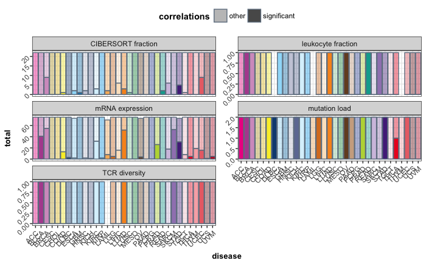

```r
bind_rows(clonality_leuk_frac_corr_df, clonality_ciber_frac_corr_df,
          clonality_mut_load_corr_df, clonality_tcr_div_corr_df,
          clonality_mrna_corr_df) %>%
    group_by(disease, correlate_type) %>%
    summarise(num_correlations = length(estimate),
              significant = sum(p.adjust < 0.05, na.rm = TRUE),
              other = num_correlations - significant) %>%
    gather(correlations, total, -disease, -correlate_type, -num_correlations) %>%
    ggplot(aes(x = disease, y = total)) +
    geom_col(aes(fill = disease, alpha = correlations), colour = "slategray") +
    theme(axis.text.x = element_text(angle = 45, hjust = 1),
          axis.text.y = element_text(angle = 45),
          legend.position = "top") +
    scale_fill_manual(values = tcga_colors$Color) +
    scale_alpha_manual(values = c(0.4, 1)) +
    guides(fill = FALSE) +
    facet_wrap(~ correlate_type, ncol = 2, scales = "free_y")
```

```r
correlate_annotations <- clonality_mrna_corr_df %>%
    select(disease, clonality, correlate, estimate, statistic, p.value, method, alternative, p.adjust, correlate_type) %>%
    bind_rows(clonality_leuk_frac_corr_df, clonality_ciber_frac_corr_df,
          clonality_mut_load_corr_df, .) %>%
    distinct(correlate, correlate_type) %>%
    left_join(gene_correlate_df,
              by = c("correlate" = "matched_name")) %>%
    mutate(label = ifelse(correlate_type == "mRNA expression",
                          `HGNC Symbol`, correlate),
           label = str_replace(correlate, "\\.\\.Tregs\\.", ""),
           label = ifelse(label == "leuk_frac", "Leukocyte Fraction", label),
           group = ifelse(correlate_type == "leukocyte fraction", "Total Immune Cells", group),
           group = ifelse(correlate_type == "mutation load", "Mutation Load", group),
           group = ifelse(correlate_type == "CIBERSORT fraction" & str_detect(label, "^(T|B)\\."),
                          "Adaptive Immune Cells", group),
           group = ifelse(correlate_type == "CIBERSORT fraction" & !str_detect(label, "^(T|B)"),
                          "Innate Immune Cells", group)) %>%
    select(correlate, correlate_type, group, label)
```

```r
clonality_sig_corr_df <- bind_rows(clonality_leuk_frac_corr_df, clonality_ciber_frac_corr_df,
          clonality_mut_load_corr_df, clonality_tcr_div_corr_df,
          clonality_mrna_corr_df) %>%
    filter(!is.na(p.adjust),
           p.adjust < 0.05) %>%
    mutate(disease = factor(disease, levels = tcga_colors$Disease)) %>%
    left_join(correlate_annotations, by = c("correlate", "correlate_type")) %>%
    filter(!is.na(group))
```

## ITH-immune associations

### With summary observations

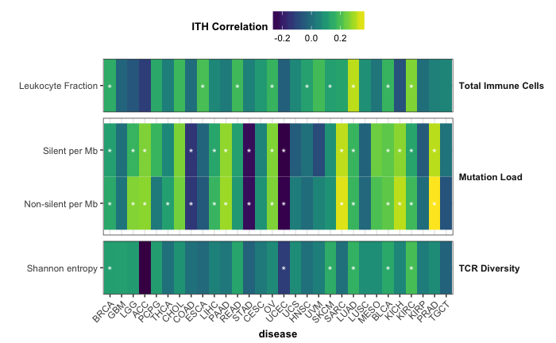

```r
# clonality_sig_corr_df %>%
bind_rows(clonality_leuk_frac_corr_df, clonality_ciber_frac_corr_df,
          clonality_mut_load_corr_df, clonality_tcr_div_corr_df,
          clonality_mrna_corr_df) %>%
    filter(!(disease %in% c("DLBC", "THYM", "LAML"))) %>%
    filter(!is.na(p.adjust)) %>%
    mutate(disease = factor(disease, levels = tcga_colors$Disease),
           significant = ifelse(p.adjust < 0.05, "*", "")) %>%
    left_join(correlate_annotations, by = c("correlate", "correlate_type")) %>%
    mutate(label = ifelse(correlate_type == "TCR diversity",
                          "Shannon entropy", label),
           group = ifelse(correlate_type == "TCR diversity",
                          "TCR Diversity", group)) %>%
    filter(!is.na(group)) %>%
    filter(!(correlate_type %in% c("mRNA expression", "CIBERSORT fraction"))) %>%
    # filter(str_detect(label, "(activated|resting)")) %>%
    mutate(group = fct_inorder(group)) %>%
    ggplot(aes(x = disease, y = label)) +
    geom_tile(aes(fill = estimate), size = 0.2) +
    geom_text(aes(label = significant), colour = "white", vjust = 0.8) +
    scale_fill_viridis("ITH Correlation") +
    ylab("") +
    theme(axis.text.x = element_text(angle = 45, hjust = 1),
          legend.position = "top",
          legend.title = element_text(size = 10),
          strip.text.x = element_text(face = "bold"),
          strip.text.y = element_text(angle = 0, face = "bold", hjust = 0),
          strip.background = element_blank()) +
    facet_grid(group ~ ., scales = "free", space = "free")
```

### With relative leukocyte fractions

```r
clonality_ciber_frac_corr_mat <- clonality_ciber_frac_corr_df %>%
    filter(!(disease %in% c("DLBC", "THYM", "LAML"))) %>%
    filter(!is.na(p.adjust)) %>%
    left_join(correlate_annotations, by = c("correlate", "correlate_type")) %>%
    filter(!is.na(group)) %>%
    select(disease, estimate, label) %>%
    spread(disease, estimate) %>%
    remove_rownames() %>%
    column_to_rownames("label") %>%
    as.matrix()
```

```
Setting row names on a tibble is deprecated.
```

```r
clonality_ciber_frac_padj_mat <- clonality_ciber_frac_corr_df %>%
    filter(!(disease %in% c("DLBC", "THYM", "LAML"))) %>%
    filter(!is.na(p.adjust)) %>%
    left_join(correlate_annotations, by = c("correlate", "correlate_type")) %>%
    filter(!is.na(group)) %>%
    mutate(p_sym = ifelse(p.adjust < 0.05, "*", "")) %>%
    select(disease, p_sym, label) %>%
    spread(disease, p_sym) %>%
    remove_rownames() %>%
    column_to_rownames("label") %>%
    as.matrix()
```

```
Setting row names on a tibble is deprecated.
```

```r
lmat <- rbind(c(6, 0, 5), c(0, 0, 2), c(4, 1, 3))
lwid <- c(1.5, 0.2, 6)
lhei <- c(2, 0.3, 6)
# PNG graphic device doesn't play well with R Notebooks; copy and paste this
# chunk to a new R script when ready to save
cairo_pdf("figures/RelLeuk-CorrITH_perStudy_20170720.pdf",
    width = 8*300, height = 6*300, fallback_resolution = 300, pointsize = 10)
col_colors <- tibble(disease = colnames(clonality_ciber_frac_corr_mat)) %>%
    left_join(clonality_sig_corr_df %>%
                  filter(correlate == "leuk_frac")) %>%
    mutate(Color = ifelse(!is.na(label), "#56B4E9", "#999999"))
row_colors <- tibble(label = rownames(clonality_ciber_frac_corr_mat)) %>%
    left_join(correlate_annotations, by = "label") %>%
    mutate(Color = case_when(
        .$group == "Adaptive Immune Cells" ~ "#333333",
        .$group == "Innate Immune Cells" ~ "#E69F00"
    ))
par(mar = c(0, 0, 0, 0))
gplots::heatmap.2(clonality_ciber_frac_corr_mat,
                  trace = "none", density.info = "none",
                  rowsep = c(8, 15), colsep = c(5, 11),
                  col = my_cet_pal,
                  cexRow = 1.3, cexCol = 1.3, notecex = 1.5,
                  cellnote = clonality_ciber_frac_padj_mat, notecol = "black",
                  ColSideColors = col_colors$Color,
                  RowSideColors = row_colors$Color,
                  lmat = lmat, lwid = lwid, lhei = lhei,
                  margins = c(5, 15), offsetCol = 0.1, offsetRow = 0.1,
                  key.title = NA, key.xlab = "ITH correlation",
                  key.par = list(mgp = c(1.5, 0.5, 0),
                                 mar = c(3, 3, 3, 1))) # change to c(5, 3, 4, 1) for saving
```

[output not shown]

[output not shown]

### With immunomodulators

```r
clonality_mrna_corr_mat <- clonality_mrna_corr_df %>%
    filter(!(disease %in% c("DLBC", "THYM", "LAML"))) %>%
    filter(!is.na(p.adjust)) %>%
    left_join(correlate_annotations, by = c("correlate", "correlate_type")) %>%
    filter(!is.na(group)) %>%
    select(disease, estimate, label) %>%
    spread(disease, estimate) %>%
    remove_rownames() %>%
    column_to_rownames("label") %>%
    as.matrix()
```

```
Setting row names on a tibble is deprecated.
```

```r
clonality_mrna_padj_mat <- clonality_mrna_corr_df %>%
    filter(!(disease %in% c("DLBC", "THYM", "LAML"))) %>%
    filter(!is.na(p.adjust)) %>%
    left_join(correlate_annotations, by = c("correlate", "correlate_type")) %>%
    filter(!is.na(group)) %>%
    mutate(p_sym = ifelse(p.adjust < 0.05, "*", "")) %>%
    select(disease, p_sym, label) %>%
    spread(disease, p_sym) %>%
    remove_rownames() %>%
    column_to_rownames("label") %>%
    as.matrix()
```

```
Setting row names on a tibble is deprecated.
```

```r
lmat <- rbind(c(5, 0, 4), c(3, 1, 2))
lwid <- c(1.5, 0.2, 6)
lhei <- c(1, 7)
# png("figures/clonality_immunomod_corr.png",
#     width = 8*300, height = 10*300, res = 300, pointsize = 10)
row_colors <- tibble(label = rownames(clonality_mrna_corr_mat)) %>%
    left_join(correlate_annotations, by = "label") %>%
    mutate(Color = case_when(
        .$group == "Checkpoint Inhibitor" ~ "#333333",
        .$group == "Checkpoint Stimulator" ~ "#E69F00",
        .$group == "Cytolytic Marker" ~ "#56B4E9",
        .$group == "MHC Class I" ~ "#009E73",
        .$group == "MHC Class II" ~ "#F0E442"
    ))
gplots::heatmap.2(clonality_mrna_corr_mat,
                  trace = "none", density.info = "none",
                  rowsep = c(44, 47, 57, 68, 71), colsep = c(5, 13, 22),
                  col = my_cet_pal,
                  notecex = 1.5, cexRow = 1.2, cexCol = 1.2,
                  cellnote = clonality_mrna_padj_mat, notecol = "black",
                  RowSideColors = row_colors$Color,
                  lmat = lmat, lwid = lwid, lhei = lhei,
                  margins = c(10, 6), offsetCol = 0.1, offsetRow = 0.1,
                  key.title = NA, key.xlab = "ITH correlation",
                  key.par = list(mgp = c(1.5, 0.5, 0),
                                 mar = c(5, 3, 4, 1)))
par(mar = c(0, 0, 0, 0))
```

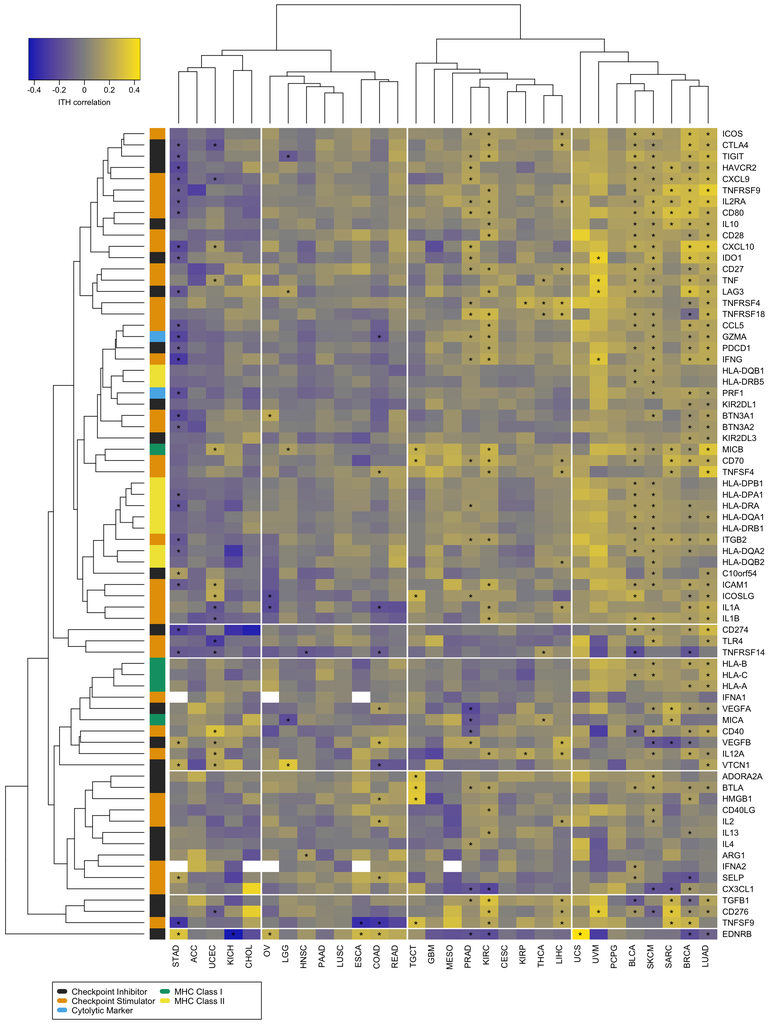

```r
legend(0, -0.025,
       legend = distinct(row_colors, group, Color)$group,
       col = distinct(row_colors, group, Color)$Color,
       horiz = FALSE, xjust = 0, yjust = 1, ncol = 2,
       lty = 1, lwd = 7, cex = 0.8, seg.len = 0.8)
```

## ITH and immune subtypes

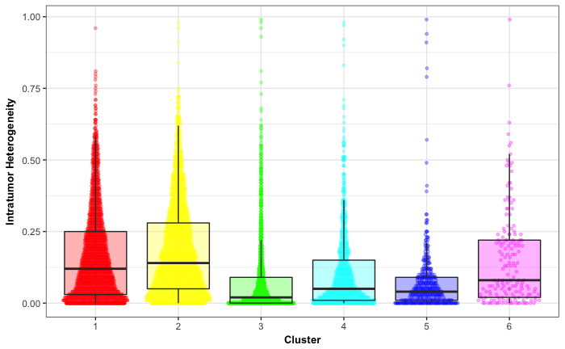

```r
plot_colors <- tcga_colors %>%
    filter(Disease %in% left_join(subtype_mclust_corr_df,
                                  clonality_corr_df,
                                  by = "vial_id")[["Disease"]])
subtype_mclust_corr_df %>%
    left_join(clonality_corr_df, by = "vial_id") %>%
    select(Disease, vial_id, ClusterModel1,
           subclonal_frac = `Subclonal genome fraction`) %>%
    mutate(ClusterModel1 = fct_reorder(as.character(ClusterModel1),
                                       ClusterModel1),
           disease = factor(Disease, levels = plot_colors$Disease)) %>%
    group_by(ClusterModel1) %>%
    mutate(med_subclonal_frac = median(subclonal_frac)) %>%
    ungroup() %>%
    # filter(Disease == "BRCA") %>%
    ggplot(aes(x = ClusterModel1, y = subclonal_frac)) +
    geom_quasirandom(aes(colour = ClusterModel1), size = 1, alpha = 0.3) +
    geom_boxplot(aes(fill = ClusterModel1), alpha = 0.3, outlier.size = 0,
                 outlier.alpha = 0) +
    scale_fill_manual(values = c("red", "yellow", "green", "cyan", "blue", "magenta")) +
    scale_colour_manual(values = c("red", "yellow", "green", "cyan", "blue", "magenta")) +
    guides(fill = FALSE, colour = FALSE) +
    xlab("Cluster") +
    ylab("Intratumor Heterogeneity")
```

```r
    # geom_boxplot(aes(fill = med_subclonal_frac), outlier.size = 0.5)
    # theme(axis.text.y = element_blank(),
    #       axis.ticks.y = element_blank(),
    #       axis.text.x = element_text(angle = 45, hjust = 1)) +
    # facet_grid(~ Disease, scales = "free", space = "free")
```